# Easy Demographic Analysis Tutorial with Python:101

*Author: Jason Li | Published: December 7, 2025*

Welcome to this demographic analysis tutorial! This guide will take you from beginner to proficient in conducting professional demographic analysis using Python.

## 🎯 What You'll Learn

By the end of this tutorial, you will be able to:

1. **Understand Core Concepts** - Master population pyramids, fertility rates, mortality rates, and more
2. **Data Processing** - Use pandas to process and clean demographic data
3. **Visualization** - Create professional demographic charts and visualizations
4. **Real-World Analysis** - Apply techniques to actual country data

## Part 1: Environment Setup and Library Imports

### Why Choose Python?

Python has become the preferred tool for demographic analysis for several compelling reasons:

1. **Rich Data Science Ecosystem** - pandas, numpy, matplotlib, seaborn, plotly
2. **Easy to Learn** - Clear syntax, suitable for researchers without programming backgrounds
3. **Reproducibility** - Code documents every analysis step, ensuring transparency
4. **Free and Open Source** - No expensive licenses required
5. **Strong Community Support** - Abundant tutorials, documentation, and examples

### Required Libraries

| Library | Purpose | Key Features |
| --- | --- | --- |
| **pandas** | Data Processing | DataFrame operations, data cleaning, statistical calculations |
| **numpy** | Numerical Computing | Array operations, mathematical functions, linear algebra |
| **matplotlib** | Basic Plotting | Static charts, custom visualizations |
| **seaborn** | Statistical Visualization | Beautiful statistical charts, heatmaps |
| **plotly** | Interactive Visualization | Dynamic charts, dashboards |
| **scipy** | Scientific Computing | Statistical tests, optimization algorithms, curve fitting |

```python
# Import core libraries
import pandas as pd
import numpy as np
import matplotlib.pyplot as plt
import seaborn as sns
import plotly.express as px
import plotly.graph_objects as go
from plotly.subplots import make_subplots
from scipy.optimize import curve_fit
from scipy import stats
import warnings

# Set display options
pd.set_option('display.max_columns', None)
pd.set_option('display.precision', 2)
warnings.filterwarnings('ignore')

# Set plotting style
plt.style.use('seaborn-v0_8-darkgrid')
sns.set_palette("husl")
plt.rcParams['figure.figsize'] = (12, 6)
plt.rcParams['font.size'] = 11

print("="*70)
print("✅ All libraries imported successfully!")
print("="*70)
print(f"\nPandas version: {pd.__version__}")
print(f"NumPy version: {np.__version__}")
print(f"\n🚀 Environment ready for demographic analysis!")
```

```
======================================================================
✅ All libraries imported successfully!
======================================================================

Pandas version: 2.3.3
NumPy version: 2.4.2

🚀 Environment ready for demographic analysis!
```

## Part 2: Population Pyramids and Age Structure

### 📊 What is a Population Pyramid?

A **Population Pyramid** is one of the most fundamental and important visualization tools in demography. It displays population distribution through horizontal bar charts showing:

- **Left Side**: Male population (by age group)
- **Right Side**: Female population (by age group)
- **Vertical Axis**: Age groups (typically 5-year intervals)
- **Horizontal Axis**: Population numbers or percentages

### 🔍 Four Basic Population Pyramid Shapes

#### 1. Expansive (Pyramid Shape)

- **Characteristics**: Wide base, narrow top
- **Meaning**: High birth rates, young population
- **Typical Countries**: Nigeria, Pakistan, Congo
- **Policy Implications**: Requires significant investment in education and employment

#### 2. Stationary (Bell Shape)

- **Characteristics**: Relatively balanced across age groups
- **Meaning**: Balanced birth and death rates
- **Typical Countries**: United States, Australia
- **Policy Implications**: Balanced social security needs

#### 3. Constrictive (Pear Shape)

- **Characteristics**: Narrowing base, expanding middle
- **Meaning**: Low birth rates, aging population
- **Typical Countries**: China, Brazil, South Korea
- **Policy Implications**: Increasing pension pressure

#### 4. Inverted (Inverted Pyramid)

- **Characteristics**: Very narrow base, wide top
- **Meaning**: Extremely low birth rates, super-aged society
- **Typical Countries**: Japan, Germany, Italy
- **Policy Implications**: Population sustainability crisis

```python
# Create sample data for four different pyramid shapes

age_groups = ['0-4', '5-9', '10-14', '15-19', '20-24', '25-29',
              '30-34', '35-39', '40-44', '45-49', '50-54', '55-59',
              '60-64', '65-69', '70-74', '75-79', '80+']

# 1. Expansive: Developing country (e.g., Nigeria)
expansive_male = [120, 115, 110, 105, 100, 95, 90, 85, 75, 65, 55, 45, 35, 25, 18, 12, 8]
expansive_female = [115, 110, 105, 100, 95, 90, 85, 80, 72, 62, 52, 42, 32, 23, 17, 11, 9]

# 2. Stationary: Developed country (e.g., USA)
stationary_male = [65, 68, 70, 72, 75, 78, 80, 82, 85, 87, 85, 80, 75, 65, 50, 35, 20]
stationary_female = [62, 65, 67, 69, 72, 75, 77, 79, 82, 84, 82, 77, 72, 62, 48, 33, 22]

# 3. Constrictive: Transitioning country (e.g., China)
constrictive_male = [55, 52, 50, 65, 85, 95, 100, 105, 110, 105, 95, 85, 70, 55, 40, 28, 15]
constrictive_female = [52, 50, 48, 62, 82, 92, 97, 102, 107, 102, 92, 82, 67, 52, 38, 26, 17]

# 4. Inverted: Super-aged country (e.g., Japan)
inverted_male = [45, 43, 42, 48, 60, 72, 85, 95, 100, 105, 108, 105, 98, 88, 75, 55, 35]
inverted_female = [43, 41, 40, 46, 58, 70, 83, 93, 98, 103, 106, 103, 96, 86, 73, 53, 38]

# Create DataFrame
pyramid_data = pd.DataFrame({
    'Age_Group': age_groups,
    'Expansive_M': expansive_male,
    'Expansive_F': expansive_female,
    'Stationary_M': stationary_male,
    'Stationary_F': stationary_female,
    'Constrictive_M': constrictive_male,
    'Constrictive_F': constrictive_female,
    'Inverted_M': inverted_male,
    'Inverted_F': inverted_female
})

print("📊 Population Pyramid Data Preview (in thousands)")
print("="*70)
print(pyramid_data.head(10))
print("\n✅ Data created successfully! Includes 4 population structure types")
```

```
📊 Population Pyramid Data Preview (in thousands)
======================================================================
  Age_Group  Expansive_M  Expansive_F  Stationary_M  Stationary_F  \
0       0-4          120          115            65            62
1       5-9          115          110            68            65
2     10-14          110          105            70            67
3     15-19          105          100            72            69
4     20-24          100           95            75            72
5     25-29           95           90            78            75
6     30-34           90           85            80            77
7     35-39           85           80            82            79
8     40-44           75           72            85            82
9     45-49           65           62            87            84

   Constrictive_M  Constrictive_F  Inverted_M  Inverted_F
0              55              52          45          43
1              52              50          43          41
2              50              48          42          40
3              65              62          48          46
4              85              82          60          58
5              95              92          72          70
6             100              97          85          83
7             105             102          95          93
8             110             107         100          98
9             105             102         105         103

✅ Data created successfully! Includes 4 population structure types
```

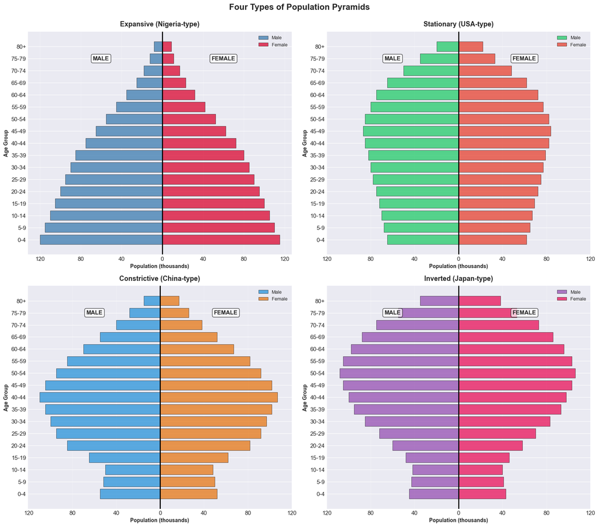

```
✅ Four population pyramids generated!

💡 Key Observations:
  • Expansive: Widest base, indicates high birth rate
  • Stationary: Relatively balanced, indicates stable population
  • Constrictive: Expanding middle, narrowing base
  • Inverted: Top-heavy, severe aging
```

```python
# Plot all four population pyramid types for comparison

fig, axes = plt.subplots(2, 2, figsize=(16, 14))
fig.suptitle('Four Types of Population Pyramids',
             fontsize=16, fontweight='bold', y=0.995)

pyramid_types = [
    ('Expansive', 'Expansive (Nigeria-type)', 0, 0, 'steelblue', 'crimson'),
    ('Stationary', 'Stationary (USA-type)', 0, 1, '#2ecc71', '#e74c3c'),
    ('Constrictive', 'Constrictive (China-type)', 1, 0, '#3498db', '#e67e22'),
    ('Inverted', 'Inverted (Japan-type)', 1, 1, '#9b59b6', '#e91e63')
]

for ptype, title, row, col, color_m, color_f in pyramid_types:
    ax = axes[row, col]

    # Get data
    male_data = -pyramid_data[f'{ptype}_M']  # Negative for left side
    female_data = pyramid_data[f'{ptype}_F']

    # Plot bars
    ax.barh(pyramid_data['Age_Group'], male_data,
            label='Male', color=color_m, alpha=0.8, edgecolor='black', linewidth=0.5)
    ax.barh(pyramid_data['Age_Group'], female_data,
            label='Female', color=color_f, alpha=0.8, edgecolor='black', linewidth=0.5)

    # Add center line
    ax.axvline(x=0, color='black', linewidth=2)

    # Set title and labels
    ax.set_title(title, fontsize=13, fontweight='bold', pad=10)
    ax.set_xlabel('Population (thousands)', fontsize=10, fontweight='bold')
    ax.set_ylabel('Age Group', fontsize=10, fontweight='bold')

    # Set x-axis ticks
    ticks = [-120, -80, -40, 0, 40, 80, 120]
    ax.set_xticks(ticks)
    ax.set_xticklabels([abs(t) for t in ticks])

    # Add grid
    ax.grid(True, alpha=0.3, axis='x')
    ax.legend(loc='upper right', fontsize=9)

    # Add text annotations
    ax.text(-60, 15, 'MALE', fontsize=11, fontweight='bold',
            ha='center', va='center', bbox=dict(boxstyle='round', facecolor='white', alpha=0.7))
    ax.text(60, 15, 'FEMALE', fontsize=11, fontweight='bold',
            ha='center', va='center', bbox=dict(boxstyle='round', facecolor='white', alpha=0.7))

plt.tight_layout()
plt.show()

print("\n✅ Four population pyramids generated!")
print("\n💡 Key Observations:")
print("  • Expansive: Widest base, indicates high birth rate")
print("  • Stationary: Relatively balanced, indicates stable population")
print("  • Constrictive: Expanding middle, narrowing base")
print("  • Inverted: Top-heavy, severe aging")
```

### 📈 Age Structure Analysis

Let's calculate key indicators for each population structure:

```python
# Calculate age structure indicators for each type

def calculate_age_structure(male_pop, female_pop, age_groups):
    """
    Calculate population age structure indicators
    """
    total_pop = male_pop + female_pop

    # Age group divisions (assuming first 3 groups are 0-14, middle 11 groups are 15-64, last 3 groups are 65+)
    youth = total_pop[:3].sum()  # 0-14 years
    working_age = total_pop[3:14].sum()  # 15-64 years
    elderly = total_pop[14:].sum()  # 65+ years
    total = total_pop.sum()

    # Calculate percentages
    youth_pct = (youth / total) * 100
    working_pct = (working_age / total) * 100
    elderly_pct = (elderly / total) * 100

    # Calculate dependency ratios
    youth_dependency = (youth / working_age) * 100
    age_dependency = (elderly / working_age) * 100
    total_dependency = youth_dependency + age_dependency

    # Calculate sex ratio (male/female × 100)
    sex_ratio = (male_pop.sum() / female_pop.sum()) * 100

    # Calculate median age (simplified estimate)
    cumsum = np.cumsum(total_pop)
    median_idx = np.searchsorted(cumsum, total / 2)
    median_age = median_idx * 5 + 2.5  # Simplified estimate

    return {
        '0-14 (%)': youth_pct,
        '15-64 (%)': working_pct,
        '65+ (%)': elderly_pct,
        'Youth Dependency': youth_dependency,
        'Age Dependency': age_dependency,
        'Total Dependency': total_dependency,
        'Sex Ratio': sex_ratio,
        'Median Age': median_age,
        'Total Pop (K)': total
    }

# Calculate indicators for each type
results = {}
for ptype in ['Expansive', 'Stationary', 'Constrictive', 'Inverted']:
    male = pyramid_data[f'{ptype}_M'].values
    female = pyramid_data[f'{ptype}_F'].values
    results[ptype] = calculate_age_structure(male, female, age_groups)

# Create results DataFrame
results_df = pd.DataFrame(results).T

print("\n" + "="*90)
print("📊 Key Indicators Comparison of Four Population Structures")
print("="*90)
print(results_df.round(2))

print("\n\n💡 Indicator Interpretation:")
print("-" * 90)
print("\n1. Expansive (Developing Countries):")
print("   • Highest 0-14 age proportion → Great future growth potential")
print("   • High youth dependency → Large education investment needs")
print("   • Low median age → Young society")

print("\n2. Stationary (Developed Countries):")
print("   • Relatively balanced age structure")
print("   • Moderate total dependency ratio")
print("   • Relatively stable population")

print("\n3. Constrictive (Transitioning Countries):")
print("   • High working-age population proportion → 'Demographic dividend' period")
print("   • But clear aging trend")
print("   • Need to prepare for future aging")

print("\n4. Inverted (Super-aged Countries):")
print("   • Highest 65+ proportion → Severe aging")
print("   • Extremely high age dependency → Huge pension pressure")
print("   • Population sustainability faces challenges")
```

```
==========================================================================================
📊 Key Indicators Comparison of Four Population Structures
==========================================================================================
              0-14 (%)  15-64 (%)  65+ (%)  Youth Dependency  Age Dependency  \
Expansive        29.89      66.78     3.32             44.76            4.97
Stationary       17.26      73.70     9.04             23.42           12.27
Constrictive     12.91      80.19     6.90             16.10            8.60
Inverted         10.20      76.58    13.22             13.33           17.26

              Total Dependency  Sex Ratio  Median Age  Total Pop (K)
Expansive                49.73     105.27        27.5         2258.0
Stationary               35.69     103.90        37.5         2300.0
Constrictive             24.70     103.60        37.5         2378.0
Inverted                 30.59     102.36        47.5         2489.0


💡 Indicator Interpretation:
------------------------------------------------------------------------------------------

1. Expansive (Developing Countries):
   • Highest 0-14 age proportion → Great future growth potential
   • High youth dependency → Large education investment needs
   • Low median age → Young society

2. Stationary (Developed Countries):
   • Relatively balanced age structure
   • Moderate total dependency ratio
   • Relatively stable population

3. Constrictive (Transitioning Countries):
   • High working-age population proportion → 'Demographic dividend' period
   • But clear aging trend
   • Need to prepare for future aging

4. Inverted (Super-aged Countries):
   • Highest 65+ proportion → Severe aging
   • Extremely high age dependency → Huge pension pressure
   • Population sustainability faces challenges
```

## Part 3: Core Demographic Indicators

### 📊 Basic Demographic Rates

The three most fundamental indicators in demography:

#### 1. Crude Birth Rate (CBR)

```
CBR = (Annual Births / Mid-year Total Population) × 1,000
```

- High CBR (>30): Developing countries
- Moderate CBR (15-30): Transitioning countries
- Low CBR (<15): Developed countries

#### 2. Crude Death Rate (CDR)

```
CDR = (Annual Deaths / Mid-year Total Population) × 1,000
```

Note: Aging countries naturally have higher CDR

#### 3. Natural Increase Rate (NIR)

```
NIR = CBR - CDR (per thousand)
or
% Growth = ((Current Year Pop - Previous Year Pop) / Previous Year Pop) × 100
```

### Real-World Case: Multi-Country Population Dynamics Comparison

```python
# Create multi-country real demographic data (based on 2023 actual data)

countries_vital_stats = {
    'Country': ['Nigeria', 'India', 'Brazil', 'China', 'Japan', 'Germany'],
    'Population (M)': [223, 1417, 215, 1425, 125, 84],
    'Births (K)': [8140, 25079, 3010, 11400, 788, 731],
    'Deaths (K)': [2051, 9919, 1613, 12540, 1438, 1059],
    'TFR': [4.9, 2.1, 1.7, 1.3, 1.2, 1.5],
    'Life Expectancy': [54.7, 70.3, 76.7, 77.5, 85.0, 81.8],
    'Median Age': [18.5, 28.1, 34.8, 38.5, 48.8, 48.0],
    'Urbanization (%)': [52, 35, 88, 64, 92, 77]
}

df_vital = pd.DataFrame(countries_vital_stats)

# Calculate demographic rates
df_vital['CBR'] = (df_vital['Births (K)'] / df_vital['Population (M)'])
df_vital['CDR'] = (df_vital['Deaths (K)'] / df_vital['Population (M)'])
df_vital['NIR'] = df_vital['CBR'] - df_vital['CDR']
df_vital['Growth (%)'] = (df_vital['NIR'] / 10).round(2)

print("\n" + "="*100)
print("🌍 Six-Country Demographic Indicators Comparison (2023 Data)")
print("="*100)

# Display basic data
print("\n📋 Basic Population Data:")
display_cols = ['Country', 'Population (M)', 'Births (K)', 'Deaths (K)']
print(df_vital[display_cols].to_string(index=False))

# Display calculated rates
print("\n\n📊 Calculated Demographic Rates:")
rate_cols = ['Country', 'CBR', 'CDR', 'NIR', 'Growth (%)']
print(df_vital[rate_cols].round(2).to_string(index=False))

# Display development indicators
print("\n\n📈 Social Development Indicators:")
dev_cols = ['Country', 'TFR', 'Life Expectancy', 'Median Age', 'Urbanization (%)']
print(df_vital[dev_cols].round(1).to_string(index=False))
```

```
====================================================================================================
🌍 Six-Country Demographic Indicators Comparison (2023 Data)
====================================================================================================

📋 Basic Population Data:
Country  Population (M)  Births (K)  Deaths (K)
Nigeria             223        8140        2051
  India            1417       25079        9919
 Brazil             215        3010        1613
  China            1425       11400       12540
  Japan             125         788        1438
Germany              84         731        1059


📊 Calculated Demographic Rates:
Country  CBR   CDR  NIR  Growth (%)
Nigeria 36.5  9.20 27.3        2.73
  India 17.7  7.00 10.7        1.07
 Brazil 14.0  7.50  6.5        0.65
  China  8.0  8.80 -0.8       -0.08
  Japan  6.3 11.50 -5.2       -0.52
Germany  8.7 12.61 -3.9       -0.39


📈 Social Development Indicators:
Country  TFR  Life Expectancy  Median Age  Urbanization (%)
Nigeria  4.9             54.7        18.5                52
  India  2.1             70.3        28.1                35
 Brazil  1.7             76.7        34.8                88
  China  1.3             77.5        38.5                64
  Japan  1.2             85.0        48.8                92
Germany  1.5             81.8        48.0                77
```

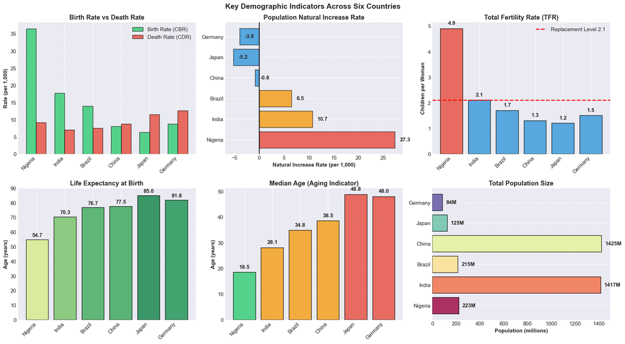

[output not shown]

```python
# Visualize demographic rates comparison

fig, axes = plt.subplots(2, 3, figsize=(18, 10))
fig.suptitle('Key Demographic Indicators Across Six Countries',
             fontsize=15, fontweight='bold')

countries = df_vital['Country'].values

# 1. Birth Rate vs Death Rate
ax1 = axes[0, 0]
x = np.arange(len(countries))
width = 0.35
ax1.bar(x - width/2, df_vital['CBR'], width, label='Birth Rate (CBR)',
        color='#2ecc71', alpha=0.8, edgecolor='black')
ax1.bar(x + width/2, df_vital['CDR'], width, label='Death Rate (CDR)',
        color='#e74c3c', alpha=0.8, edgecolor='black')
ax1.set_ylabel('Rate (per 1,000)', fontweight='bold')
ax1.set_title('Birth Rate vs Death Rate', fontweight='bold')
ax1.set_xticks(x)
ax1.set_xticklabels(countries, rotation=45, ha='right')
ax1.legend()
ax1.grid(True, alpha=0.3, axis='y')

# 2. Natural Increase Rate
ax2 = axes[0, 1]
colors_growth = ['#e74c3c' if x > 20 else '#f39c12' if x > 5 else '#2ecc71' if x > 0 else '#3498db'
                 for x in df_vital['NIR']]
ax2.barh(countries, df_vital['NIR'], color=colors_growth, alpha=0.8, edgecolor='black')
ax2.set_xlabel('Natural Increase Rate (per 1,000)', fontweight='bold')
ax2.set_title('Population Natural Increase Rate', fontweight='bold')
ax2.axvline(x=0, color='black', linewidth=1.5)
ax2.grid(True, alpha=0.3, axis='x')
for i, v in enumerate(df_vital['NIR']):
    ax2.text(v + 1, i, f'{v:.1f}', va='center', fontweight='bold')

# 3. Total Fertility Rate
ax3 = axes[0, 2]
colors_tfr = ['#e74c3c' if x > 3.5 else '#f39c12' if x > 2.1 else '#3498db'
              for x in df_vital['TFR']]
ax3.bar(countries, df_vital['TFR'], color=colors_tfr, alpha=0.8, edgecolor='black', linewidth=1.2)
ax3.axhline(y=2.1, color='red', linestyle='--', linewidth=2, label='Replacement Level 2.1')
ax3.set_ylabel('Children per Woman', fontweight='bold')
ax3.set_title('Total Fertility Rate (TFR)', fontweight='bold')
ax3.set_xticklabels(countries, rotation=45, ha='right')
ax3.legend()
ax3.grid(True, alpha=0.3, axis='y')
for i, v in enumerate(df_vital['TFR']):
    ax3.text(i, v + 0.15, f'{v:.1f}', ha='center', fontweight='bold')

# 4. Life Expectancy
ax4 = axes[1, 0]
colors_le = plt.cm.RdYlGn(df_vital['Life Expectancy'] / 90)
ax4.bar(countries, df_vital['Life Expectancy'], color=colors_le, alpha=0.8, edgecolor='black', linewidth=1.2)
ax4.set_ylabel('Age (years)', fontweight='bold')
ax4.set_title('Life Expectancy at Birth', fontweight='bold')
ax4.set_xticklabels(countries, rotation=45, ha='right')
ax4.set_ylim([0, 90])
ax4.grid(True, alpha=0.3, axis='y')
for i, v in enumerate(df_vital['Life Expectancy']):
    ax4.text(i, v + 2, f'{v:.1f}', ha='center', fontweight='bold')

# 5. Median Age
ax5 = axes[1, 1]
colors_age = ['#2ecc71' if x < 25 else '#f39c12' if x < 40 else '#e74c3c'
              for x in df_vital['Median Age']]
ax5.bar(countries, df_vital['Median Age'], color=colors_age, alpha=0.8, edgecolor='black', linewidth=1.2)
ax5.set_ylabel('Age (years)', fontweight='bold')
ax5.set_title('Median Age (Aging Indicator)', fontweight='bold')
ax5.set_xticklabels(countries, rotation=45, ha='right')
ax5.grid(True, alpha=0.3, axis='y')
for i, v in enumerate(df_vital['Median Age']):
    ax5.text(i, v + 1.5, f'{v:.1f}', ha='center', fontweight='bold')

# 6. Population Size
ax6 = axes[1, 2]
colors_pop = plt.cm.Spectral(np.linspace(0, 1, len(countries)))
ax6.barh(countries, df_vital['Population (M)'], color=colors_pop, alpha=0.8, edgecolor='black', linewidth=1.2)
ax6.set_xlabel('Population (millions)', fontweight='bold')
ax6.set_title('Total Population Size', fontweight='bold')
ax6.grid(True, alpha=0.3, axis='x')
for i, v in enumerate(df_vital['Population (M)']):
    ax6.text(v + 30, i, f'{v}M', va='center', fontweight='bold')

plt.tight_layout()
plt.show()

print("\n✅ Visualization complete!")
print("\n💡 Key Findings:")
print("  🔴 Nigeria: Extremely high growth rate (27‰), young population")
print("  🟡 India: Fertility rate near replacement level (2.1)")
print("  🟢 Brazil: In transition, fertility below replacement level")
print("  🔵 China: Low fertility (1.3), population about to decline")
print("  🟣 Japan: Super-aged society, population already declining")
print("  🟠 Germany: Low fertility, relies on immigration to maintain population")
```

### 📐 Formula Summary

| Indicator | Formula | Unit |
| --- | --- | --- |
| **Crude Birth Rate (CBR)** | (Births / Total Population) × 1,000 | ‰ |
| **Crude Death Rate (CDR)** | (Deaths / Total Population) × 1,000 | ‰ |
| **Natural Increase Rate (NIR)** | CBR - CDR | ‰ |
| **Growth Rate (%)** | NIR / 10 | % |
| **Total Fertility Rate (TFR)** | Average children per woman | Children/Woman |
| **Infant Mortality Rate (IMR)** | (Deaths under 1 year / Live Births) × 1,000 | ‰ |
| **Age-Specific Fertility Rate** | Σ(Fertility rates by age group) | - |

## Conclusion

### What We've Covered

In this tutorial, you've learned:

1. ✅ **Fundamental Concepts**: Population pyramids, birth rates, death rates, growth rates, dependency ratios
2. ✅ **Practical Analysis**: Calculating demographic indicators and visualizing data
3. ✅ **Real-World Applications**: Understanding demographic transitions and policy implications

### Key Takeaways

- **Demographics Shape Policy**: Population age structure, growth rates, and transitions have profound implications for education, healthcare, employment, and social security
- **Python is Powerful**: With pandas, matplotlib, and basic statistics, you can conduct meaningful demographic analysis
- **Context Matters**: Numbers alone don't tell the story—understand the historical, economic, and social context
- **Reproducibility is Essential**: Document your code and assumptions so others can verify and build upon your work

### Next Steps

1. **Work with Real Data** - Use World Bank data, UN Population Division, or national statistical offices
2. **Advanced Techniques** - Learn cohort component method, life table construction, multistate models
3. **Specialization** - Explore health demography, economic demography, or environmental demography
4. **Tools** - Explore specialized packages like DemoTools, or visualization tools like Plotly Dash

**Thank you for working through this demographic analysis tutorial!**